# Comorbidity_Mapping_Demo

Meg Hutch, Trang Le

1/15/2021

## Import Data

Replace path of simulated_data with that of your site’s Phase2.1 LocalPatientObservations csv file.

```r
data <- read.csv("data/simulated_data.csv")
```

# Elixhauser Comorbidity Mapping

## Map Elixhauser Comorbidities

t1: earliest time point to consider comorbidities t2: latest time point to consider comorbidities example <- t1 = -365, and t2 = -1 will map all all codes up to a year prior but before admission (admission = day 0)

```r
comorb_names_elix <- get_quan_elix_names()
comorbs_elix <- as.vector(comorb_names_elix$Abbreviation)

comorb_elix <- map_char_elix_codes(
  df = data,
  comorb_names = comorb_names_elix,
  t1 = -365,
  t2 = -15,
  map_type = 'elixhauser',
  truncate = TRUE
)
```

1- Dataframe of the Charlson/Elixhauser comorbidity index scores

2- Dataframe of the specific mapped codes arranged by frequency. Comorbidity mapping of all patients with ICD codes prior to admission, regardless of whether or not they had a comorbidity.

```r
index_scores_elix <- comorb_elix$index_scores %>%
  rename('elixhauser_score' = van_walraven_score)

# van Walraven is a modification of Elixhauser comorbidity measure
# doi.org/10.1097/MLR.0b013e31819432e5
mapped_codes_table_elix <- comorb_elix$mapped_codes_table

comorb_names_elix$Abbreviation <- as.character(comorb_names_elix$Abbreviation)
```

### Patient Level Comorbidity Scores

```r
index_scores_elix %>%
  datatable()
```

|  | patient_num | elixhauser_score | CHF | Arrhythmia | Valvular | PHTN | PVD | HTN | Paralysis | NeuroOther | Pulmonary | DM | DMcx | Hypothyroid | Renal | Liver | PUD | HIV | Lymphoma | Mets | Tumor | Rheumatic | Coagulopathy | Obesity | WeightLoss | FluidsLytes | BloodLoss | Anemia | Alcohol | … |
| --- | --- | --- | --- | --- | --- | --- | --- | --- | --- | --- | --- | --- | --- | --- | --- | --- | --- | --- | --- | --- | --- | --- | --- | --- | --- | --- | --- | --- | --- | --- |
| 1 | 37 | 15 | 0 | 0 | 0 | 0 | 0 | 0 | 0 | 1 | 0 | 0 | 0 | 0 | 0 | 0 | 0 | 0 | 1 | 0 | 0 | 0 | 0 | 0 | 0 | 0 | 0 | 0 | 0 | … |
| 2 | 58 | 15 | 0 | 0 | 0 | 0 | 0 | 0 | 0 | 0 | 0 | 0 | 0 | 0 | 0 | 0 | 0 | 0 | 1 | 0 | 0 | 0 | 0 | 0 | 1 | 0 | 0 | 0 | 0 | … |
| 3 | 80 | 15 | 0 | 0 | 1 | 0 | 0 | 0 | 0 | 0 | 0 | 0 | 0 | 0 | 1 | 1 | 0 | 0 | 0 | 0 | 0 | 0 | 0 | 0 | 0 | 0 | 0 | 0 | 0 | … |
| 4 | 31 | 13 | 0 | 0 | 0 | 0 | 0 | 0 | 0 | 0 | 0 | 0 | 0 | 0 | 0 | 0 | 0 | 0 | 1 | 0 | 1 | 0 | 0 | 0 | 0 | 0 | 0 | 0 | 0 | … |
| 5 | 35 | 13 | 0 | 0 | 0 | 0 | 0 | 0 | 1 | 1 | 0 | 0 | 0 | 0 | 0 | 0 | 0 | 0 | 0 | 0 | 0 | 0 | 0 | 0 | 0 | 0 | 0 | 0 | 0 | … |
| 6 | 39 | 13 | 0 | 0 | 0 | 0 | 0 | 0 | 0 | 0 | 0 | 0 | 0 | 0 | 0 | 0 | 0 | 0 | 1 | 0 | 1 | 1 | 0 | 0 | 0 | 0 | 0 | 0 | 0 | … |
| 7 | 64 | 12 | 0 | 0 | 0 | 0 | 0 | 0 | 0 | 0 | 0 | 0 | 0 | 0 | 0 | 0 | 0 | 0 | 0 | 1 | 1 | 0 | 0 | 0 | 0 | 0 | 0 | 0 | 0 | … |
| 8 | 100 | 11 | 0 | 0 | 0 | 0 | 0 | 0 | 0 | 0 | 0 | 0 | 0 | 0 | 0 | 1 | 0 | 0 | 0 | 0 | 0 | 0 | 0 | 0 | 0 | 0 | 0 | 0 | 0 | … |
| 9 | 61 | 11 | 0 | 0 | 0 | 0 | 0 | 0 | 0 | 0 | 0 | 0 | 0 | 0 | 0 | 1 | 0 | 0 | 0 | 0 | 0 | 0 | 0 | 0 | 0 | 0 | 0 | 0 | 1 | … |
| 10 | 7 | 10 | 0 | 1 | 0 | 0 | 0 | 0 | 0 | 0 | 0 | 0 | 0 | 0 | 1 | 0 | 0 | 0 | 0 | 0 | 0 | 0 | 0 | 0 | 0 | 0 | 0 | 0 | 0 | … |

[output cut: 90 more lines]

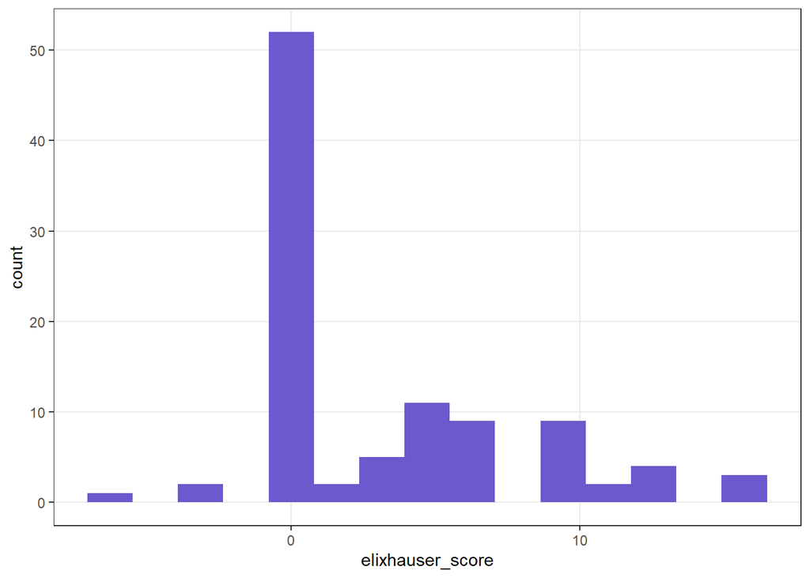

```r
ggplot(index_scores_elix, aes(x = elixhauser_score)) +
  geom_histogram(bins = 15, fill = 'slateblue')
```

### Number of patients with specific comorbidities

```r
mapped_codes_table_elix %>%
  datatable()
```

|  | concept_code | Abbreviation | long_desc | n_patients |
| --- | --- | --- | --- | --- |
| 1 | 201 | Lymphoma | Hodgkin's disease | 4 |
| 2 | 202 | Lymphoma | Other malignant neoplasms of lymphoid and histiocytic tissue | 4 |
| 3 | 711 | Rheumatic | Arthropathy associated with infections | 3 |
| 4 | 147 | Tumor | Malignant neoplasm of nasopharynx | 2 |
| 5 | 160 | Tumor | Malignant neoplasm of nasal cavities, middle ear, and accessory sinuses | 2 |
| 6 | 180 | Tumor | Malignant neoplasm of cervix uteri | 2 |
| 7 | 200 | Lymphoma | Lymphosarcoma and reticulosarcoma and other specified malignant tumors of lymphatic tissue | 2 |
| 8 | 296 | Depression | Episodic mood disorders | 2 |
| 9 | 296 | Psychoses | Episodic mood disorders | 2 |
| 10 | 531 | PUD | Gastric ulcer | 2 |

[output cut: 59 more lines]

# Charlson Comorbidity Mapping

## Map Charlson Comorbidities

t1: earliest time point to consider comorbidities t2: latest time point to consider comorbidities example <- t1 = -365, and t2 = -1 will map all all codes up to a year prior but before admission (admission = day 0)

```r
comorb_names_char <- get_charlson_names()
comorbs_char <- as.vector(comorb_names_char$Abbreviation)

comorb_char <- map_char_elix_codes(
  df = data,
  comorb_names = comorb_names_char,
  t1 = -365,
  t2 = -15,
  map_type = 'charlson',
  truncate = TRUE
)
```

1- Dataframe of the Charlson/Elixhauser comorbidity index scores

2- Dataframe of the specific mapped codes arranged by frequency. Comorbidity mapping of all patients with ICD codes prior to admission, regardless of whether or not they had a comorbidity.

```r
index_scores_char <- comorb_char$index_scores

mapped_codes_table_char <- comorb_char$mapped_codes_table

comorb_names_char$Abbreviation <- as.character(comorb_names_char$Abbreviation)
```

### Patient Level Comorbidity Scores

```r
index_scores_char %>%
  datatable()
```

|  | patient_num | charlson_score | MI | CHF | PVD | Stroke | Dementia | Pulmonary | Rheumatic | PUD | LiverMild | DM | DMcx | Paralysis | Renal | Cancer | LiverSevere | Mets | HIV |
| --- | --- | --- | --- | --- | --- | --- | --- | --- | --- | --- | --- | --- | --- | --- | --- | --- | --- | --- | --- |
| 1 | 64 | 6 | 0 | 0 | 0 | 0 | 0 | 0 | 0 | 0 | 0 | 0 | 0 | 0 | 0 | 1 | 0 | 1 | 0 |
| 2 | 87 | 4 | 0 | 0 | 0 | 0 | 0 | 0 | 0 | 0 | 0 | 0 | 0 | 0 | 1 | 1 | 0 | 0 | 0 |
| 3 | 19 | 3 | 0 | 0 | 1 | 0 | 0 | 0 | 0 | 0 | 0 | 0 | 0 | 0 | 0 | 1 | 0 | 0 | 0 |
| 4 | 7 | 3 | 1 | 0 | 0 | 0 | 0 | 0 | 0 | 0 | 0 | 0 | 0 | 0 | 1 | 0 | 0 | 0 | 0 |
| 5 | 73 | 3 | 0 | 0 | 0 | 0 | 0 | 0 | 0 | 0 | 0 | 0 | 0 | 0 | 0 | 0 | 1 | 0 | 0 |
| 6 | 77 | 3 | 0 | 0 | 0 | 0 | 0 | 0 | 0 | 1 | 0 | 0 | 0 | 0 | 0 | 1 | 0 | 0 | 0 |
| 7 | 80 | 3 | 0 | 0 | 0 | 0 | 0 | 0 | 0 | 0 | 1 | 0 | 0 | 0 | 1 | 0 | 0 | 0 | 0 |
| 8 | 12 | 2 | 0 | 0 | 0 | 1 | 0 | 0 | 1 | 0 | 0 | 0 | 0 | 0 | 0 | 0 | 0 | 0 | 0 |
| 9 | 13 | 2 | 0 | 0 | 0 | 0 | 0 | 0 | 0 | 0 | 0 | 0 | 0 | 0 | 0 | 1 | 0 | 0 | 0 |
| 10 | 14 | 2 | 0 | 0 | 0 | 0 | 0 | 0 | 0 | 0 | 0 | 0 | 0 | 0 | 0 | 1 | 0 | 0 | 0 |

[output cut: 90 more lines]

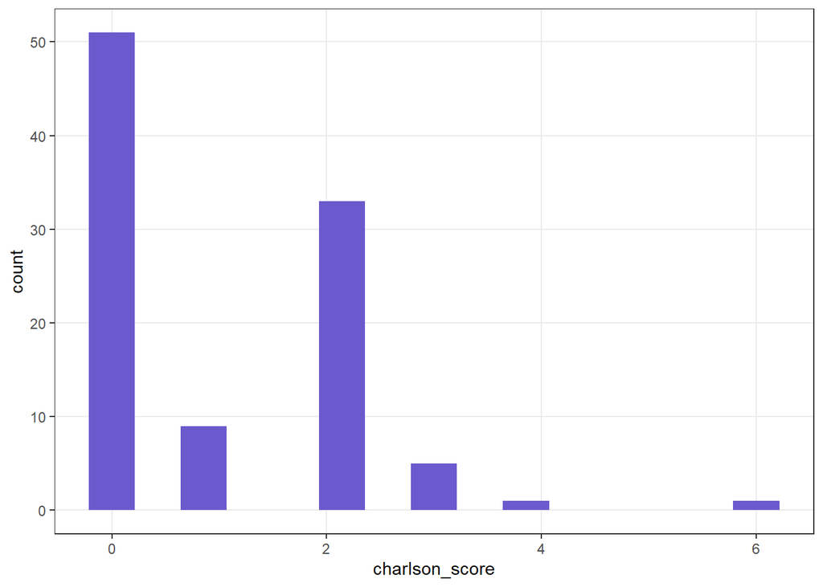

```r
ggplot(index_scores_char, aes(x = charlson_score)) +
  geom_histogram(bins = 15, fill = 'slateblue')
```

### Number of patients with specific comorbidities

```r
mapped_codes_table_char %>%
  datatable()
```

|  | concept_code | Abbreviation | long_desc | n_patients |
| --- | --- | --- | --- | --- |
| 1 | 201 | Cancer | Hodgkin's disease | 4 |
| 2 | 202 | Cancer | Other malignant neoplasms of lymphoid and histiocytic tissue | 4 |
| 3 | 147 | Cancer | Malignant neoplasm of nasopharynx | 2 |
| 4 | 160 | Cancer | Malignant neoplasm of nasal cavities, middle ear, and accessory sinuses | 2 |
| 5 | 180 | Cancer | Malignant neoplasm of cervix uteri | 2 |
| 6 | 200 | Cancer | Lymphosarcoma and reticulosarcoma and other specified malignant tumors of lymphatic tissue | 2 |
| 7 | 362 | Stroke | Other retinal disorders | 2 |
| 8 | 531 | PUD | Gastric ulcer | 2 |
| 9 | 583 | Renal | Nephritis and nephropathy, not specified as acute or chronic | 2 |
| 10 | I70 | PVD | Atherosclerosis | 2 |

[output cut: 41 more lines]